# CTGAN Synthetic Data Generation for Class Imbalance

## Overview

Generate synthetic click examples using CTGAN to address class imbalance (98.5% no-clicks vs 1.5% clicks).

**Hybrid Approach**:

- Work with raw data before encoding
- Apply CTGAN-specific preprocessing (target encode very high-cardinality features)
- Generate synthetic clicks to achieve 85-15 ratio
- Apply standard encoding pipeline before modeling

**Data Flow**:

1. Load and merge raw data from CSV files
2. Target encode very high-cardinality features (1000+ unique values)
3. Group rare categories for medium-cardinality features (100-1000 unique)
4. Prepare data for CTGAN (hybrid preprocessing)
5. Train CTGAN on minority class (clicks only)
6. Generate synthetic clicks to achieve 85-15 ratio
7. Combine real + synthetic data
8. Apply standard encoding pipeline
9. Train and evaluate logistic regression
10. Compare against baseline models

## 1. Import Libraries

```python
import numpy as np
import pandas as pd
import matplotlib.pyplot as plt
import seaborn as sns
import gc
import pickle
from sklearn.preprocessing import StandardScaler
from sklearn.linear_model import LogisticRegression
from sklearn.metrics import (
    accuracy_score, precision_score, recall_score, f1_score,
    roc_auc_score, log_loss, confusion_matrix,
    RocCurveDisplay, PrecisionRecallDisplay
)
from sklearn.model_selection import train_test_split

# Set random seed for reproducibility
SEED = 2025
np.random.seed(SEED)

# Display settings
%matplotlib inline
sns.set_style('whitegrid')
pd.set_option('display.max_columns', None)
pd.set_option('display.max_rows', 100)

print("Libraries imported successfully")
```

```
Libraries imported successfully
```

## 2. Load and Merge Raw Data

Load original CSV files and perform same merging process as `data_preprocessing.py`:

- Load user-level data (`train_data_ads.csv`) and interaction data (`train_data_feeds.csv`)
- Create user aggregation features from feeds data
- Merge user aggregates back to user data
- Verify merged data structure and class distribution

```python
def to01(s):
    """Convert label from -1/1 to 0/1"""
    s = s.copy()
    s = s.replace({-1: 0, 1: 1})
    return s.astype(int)

def safe_keep(df, cols, name):
    """Safely keep columns, reporting missing ones"""
    keep = [c for c in cols if c in df.columns]
    miss = [c for c in cols if c not in df.columns]
    if miss:
        print(f"[{name}] missing in the dataset: {miss}")
    return keep

print("Loading data...")
train_user = pd.read_csv('train_data_ads.csv')
train_adv = pd.read_csv('train_data_feeds.csv')

print(f"User data shape: {train_user.shape}")
print(f"Feeds data shape: {train_adv.shape}")

# Rename user_id column in feeds data
train_adv.rename(columns={'u_userId': 'user_id'}, inplace=True)

# Define variables to keep - using all available features for CTGAN
user_var = [
    'user_id', 'log_id', 'label',
    'age', 'gender', 'residence', 'city',
    'device_name', 'device_size', 'net_type',
    'task_id', 'adv_id', 'adv_prim_id', 'creat_type_cd',
    'city_rank', 'slot_id', 'spread_app_id',
    'inter_type_cd', 'series_group', 'series_dev', 'emui_dev',
    'hispace_app_tags', 'app_second_class', 'site_id'
]

adv_var = ['user_id', 'label']

# Safe keep columns
train_user_cols = safe_keep(train_user, user_var, "train_user")
train_adv_cols = safe_keep(train_adv, adv_var, "train_adv")

train_user = train_user[train_user_cols]
train_adv = train_adv[train_adv_cols]

print("\nData loaded successfully")
```

```
Loading data...
User data shape: (7675517, 35)
Feeds data shape: (3227732, 28)

Data loaded successfully
```

```python
# Create user aggregation features from feeds data
print("Creating user aggregation features...")

train_adv['label01'] = to01(train_adv['label'])

user_agg = (
    train_adv
    .groupby('user_id', as_index=False)
    .agg(
        feeds_imps=('label01', 'count'),
        feeds_clicks=('label01', 'sum'),
        feeds_ctr=('label01', 'mean')
    )
)

print(f"User aggregates shape: {user_agg.shape}")
print("\nSample aggregates:")
print(user_agg.head())
```

```
Creating user aggregation features...
User aggregates shape: (180123, 4)

Sample aggregates:
   user_id  feeds_imps  feeds_clicks  feeds_ctr
0   100001           6             0   0.000000
1   100002           3             0   0.000000
2   100003           6             1   0.166667
3   100005           5             0   0.000000
4   100006          26             5   0.192308
```

```python
# Merge user data with aggregates
print("Merging user data with aggregates...")
train_merged = train_user.merge(user_agg, on='user_id', how='left')

# Fill missing values
for c in ['feeds_imps', 'feeds_clicks', 'feeds_ctr']:
    if c in train_merged.columns:
        fill_val = 0 if c != 'feeds_ctr' else train_merged[c].mean()
        train_merged[c] = train_merged[c].fillna(fill_val)

# Convert label to 0/1
train_merged['label'] = to01(train_merged['label'])

print(f"\nMerged data shape: {train_merged.shape}")
print(f"Columns: {list(train_merged.columns)}")

# Clean up memory
del train_user, train_adv, user_agg
gc.collect()

print("\nMerge complete!")
```

```
Merging user data with aggregates...

Merged data shape: (7675517, 27)
Columns: ['user_id', 'log_id', 'label', 'age', 'gender', 'residence', 'city', 'device_name', 'device_size', 'net_type', 'task_id', 'adv_id', 'adv_prim_id', 'creat_type_cd', 'city_rank', 'slot_id', 'spread_app_id', 'inter_type_cd', 'series_group', 'series_dev', 'emui_dev', 'hispace_app_tags', 'app_se…

Merge complete!
```

## 3. Verify Data Structure and Class Distribution

```
================================================================================
MERGED DATA SUMMARY
================================================================================

Shape: (7675517, 27)

Data types:
user_id               int64
log_id                int64
label                 int64
age                   int64
gender                int64
residence             int64
city                  int64
device_name           int64
device_size           int64
net_type              int64
task_id               int64
adv_id                int64
adv_prim_id           int64
creat_type_cd         int64
city_rank             int64
slot_id               int64
spread_app_id         int64
inter_type_cd         int64
series_group          int64
series_dev            int64
emui_dev              int64
hispace_app_tags      int64
app_second_class      int64
site_id               int64
feeds_imps            int64
feeds_clicks          int64
feeds_ctr           float64
dtype: object

================================================================================
CLASS DISTRIBUTION
================================================================================

No-clicks (0): 7,556,381 (98.45%)
Clicks (1): 119,136 (1.55%)

Imbalance ratio: 63.43:1
```

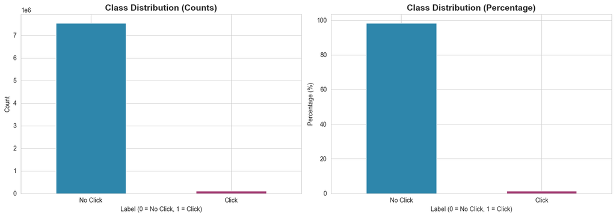

```python
# Check data info
print("=" * 80)
print("MERGED DATA SUMMARY")
print("=" * 80)
print(f"\nShape: {train_merged.shape}")
print(f"\nData types:")
print(train_merged.dtypes)

print("\n" + "=" * 80)
print("CLASS DISTRIBUTION")
print("=" * 80)
class_dist = train_merged['label'].value_counts().sort_index()
print(f"\nNo-clicks (0): {class_dist[0]:,} ({class_dist[0]/len(train_merged)*100:.2f}%)")
print(f"Clicks (1): {class_dist[1]:,} ({class_dist[1]/len(train_merged)*100:.2f}%)")
print(f"\nImbalance ratio: {class_dist[0]/class_dist[1]:.2f}:1")

# Visualize class distribution
fig, ax = plt.subplots(1, 2, figsize=(14, 5))

# Count plot
class_dist.plot(kind='bar', ax=ax[0], color=['#2E86AB', '#A23B72'])
ax[0].set_title('Class Distribution (Counts)', fontsize=14, fontweight='bold')
ax[0].set_xlabel('Label (0 = No Click, 1 = Click)')
ax[0].set_ylabel('Count')
ax[0].set_xticklabels(['No Click', 'Click'], rotation=0)

# Percentage plot
(class_dist / len(train_merged) * 100).plot(kind='bar', ax=ax[1], color=['#2E86AB', '#A23B72'])
ax[1].set_title('Class Distribution (Percentage)', fontsize=14, fontweight='bold')
ax[1].set_xlabel('Label (0 = No Click, 1 = Click)')
ax[1].set_ylabel('Percentage (%)')
ax[1].set_xticklabels(['No Click', 'Click'], rotation=0)

plt.tight_layout()
plt.show()
```

```python
# Analyze feature cardinality
print("=" * 80)
print("FEATURE CARDINALITY ANALYSIS")
print("=" * 80)

cardinality = {}
for col in train_merged.columns:
    if col not in ['user_id', 'log_id', 'label']:
        n_unique = train_merged[col].nunique()
        cardinality[col] = n_unique

cardinality_df = pd.DataFrame.from_dict(
    cardinality, orient='index', columns=['Unique Values']
).sort_values('Unique Values', ascending=False)

# Categorize by cardinality
cardinality_df['Category'] = pd.cut(
    cardinality_df['Unique Values'],
    bins=[-1, 10, 100, 1000, np.inf],
    labels=['Low (≤10)', 'Medium (11-100)', 'High (101-1000)', 'Very High (1000+)']
)

print("\nCardinality by feature:")
print(cardinality_df)

print("\n" + "=" * 80)
print("ENCODING STRATEGY")
print("=" * 80)
print("\nLow cardinality (≤10) - Keep as categorical for CTGAN:")
low_card = cardinality_df[cardinality_df['Category'] == 'Low (≤10)'].index.tolist()
for feat in low_card:
    print(f"  - {feat} ({cardinality_df.loc[feat, 'Unique Values']} unique)")

print("\nMedium cardinality (11-100) - Keep as categorical, may group rare:")
med_card = cardinality_df[cardinality_df['Category'] == 'Medium (11-100)'].index.tolist()
for feat in med_card:
    print(f"  - {feat} ({cardinality_df.loc[feat, 'Unique Values']} unique)")

print("\nHigh cardinality (101-1000) - Group rare categories:")
high_card = cardinality_df[cardinality_df['Category'] == 'High (101-1000)'].index.tolist()
for feat in high_card:
    print(f"  - {feat} ({cardinality_df.loc[feat, 'Unique Values']} unique)")

print("\nVery high cardinality (1000+) - Target encode to continuous:")
very_high_card = cardinality_df[cardinality_df['Category'] == 'Very High (1000+)'].index.tolist()
for feat in very_high_card:
    print(f"  - {feat} ({cardinality_df.loc[feat, 'Unique Values']} unique)")
```

```
================================================================================
FEATURE CARDINALITY ANALYSIS
================================================================================
```

```
Cardinality by feature:
                  Unique Values           Category
adv_id                    12615  Very High (1000+)
task_id                   11209  Very High (1000+)
feeds_ctr                  3370  Very High (1000+)
device_size                1547  Very High (1000+)
adv_prim_id                 545    High (101-1000)
feeds_imps                  500    High (101-1000)
city                        341    High (101-1000)
device_name                 256    High (101-1000)
spread_app_id               116    High (101-1000)
feeds_clicks                 72    Medium (11-100)
slot_id                      60    Medium (11-100)
hispace_app_tags             43    Medium (11-100)
residence                    35    Medium (11-100)
series_dev                   27    Medium (11-100)
emui_dev                     27    Medium (11-100)
app_second_class             20    Medium (11-100)
creat_type_cd                 9          Low (≤10)
age                           8          Low (≤10)
series_group                  7          Low (≤10)
net_type                      6          Low (≤10)
city_rank                     4          Low (≤10)
inter_type_cd                 4          Low (≤10)
gender                        3          Low (≤10)
site_id                       1          Low (≤10)

================================================================================
ENCODING STRATEGY
================================================================================

Low cardinality (≤10) - Keep as categorical for CTGAN:
  - creat_type_cd (9 unique)
  - age (8 unique)
  - series_group (7 unique)
  - net_type (6 unique)
  - city_rank (4 unique)
  - inter_type_cd (4 unique)
  - gender (3 unique)
  - site_id (1 unique)

Medium cardinality (11-100) - Keep as categorical, may group rare:
  - feeds_clicks (72 unique)
  - slot_id (60 unique)
  - hispace_app_tags (43 unique)
  - residence (35 unique)
  - series_dev (27 unique)
  - emui_dev (27 unique)
  - app_second_class (20 unique)

High cardinality (101-1000) - Group rare categories:
  - adv_prim_id (545 unique)
  - feeds_imps (500 unique)
  - city (341 unique)
  - device_name (256 unique)
  - spread_app_id (116 unique)

Very high cardinality (1000+) - Target encode to continuous:
  - adv_id (12615 unique)
  - task_id (11209 unique)
  - feeds_ctr (3370 unique)
  - device_size (1547 unique)
```

## 4. Target Encode Very High-Cardinality Features

**Goal**: Convert very high-cardinality features (1000+ unique values) to continuous features via target encoding BEFORE CTGAN training.

**Rationale**: CTGAN struggles with 10K+ categories. Target encoding converts these to continuous numeric features that CTGAN can model effectively.

**Features to encode**:

- `task_id` (11,209 unique)
- `adv_id` (12,615 unique) - if present
- `device_size` (1,547 unique)

```python
def target_encode_for_ctgan(df, column, target='label'):
    """
    Apply target encoding to a high-cardinality feature.

    Args:
        df: DataFrame containing the data
        column: Column name to encode
        target: Target column name (default: 'label')

    Returns:
        df: DataFrame with new encoded column and original column removed
        encoding_map: Dictionary mapping original values to encoded values
    """
    # Compute mean target value for each category
    encoding_map = df.groupby(column)[target].mean().to_dict()

    # Create new encoded column
    encoded_col_name = f"{column}_encoded"
    df[encoded_col_name] = df[column].map(encoding_map)

    # Fill missing values with global mean
    global_mean = df[target].mean()
    df[encoded_col_name] = df[encoded_col_name].fillna(global_mean)

    # Drop original column
    df = df.drop(columns=[column])

    return df, encoding_map

print("Target encoding function defined")
```

```
Target encoding function defined
```

```python
# Apply target encoding to very high-cardinality features
print("Applying target encoding to very high-cardinality features...\n")

# Store encoding maps for reference
encoding_maps = {}

# Features to encode (1000+ unique values)
very_high_card_features = ['task_id', 'device_size']

# Add adv_id if present (might be dropped in preprocessing)
if 'adv_id' in train_merged.columns:
    very_high_card_features.append('adv_id')

train_processed = train_merged.copy()

for feat in very_high_card_features:
    if feat in train_processed.columns:
        print(f"Encoding {feat}...")
        n_unique_before = train_processed[feat].nunique()

        train_processed, encoding_map = target_encode_for_ctgan(
            train_processed, feat, target='label'
        )

        encoding_maps[feat] = encoding_map

        encoded_col = f"{feat}_encoded"
        print(f"  Original unique values: {n_unique_before}")
        print(f"  Encoded column: {encoded_col}")
        print(f"  Encoded range: [{train_processed[encoded_col].min():.6f}, {train_processed[encoded_col].max():.6f}]")
        print(f"  Encoded mean: {train_processed[encoded_col].mean():.6f}\n")

print("Target encoding complete!")
print(f"\nProcessed data shape: {train_processed.shape}")
```

```
Applying target encoding to very high-cardinality features...

Encoding task_id...
  Original unique values: 11209
  Encoded column: task_id_encoded
  Encoded range: [0.000000, 1.000000]
  Encoded mean: 0.015522

Encoding device_size...
  Original unique values: 1547
  Encoded column: device_size_encoded
  Encoded range: [0.000000, 1.000000]
  Encoded mean: 0.015522

Encoding adv_id...
  Original unique values: 12615
  Encoded column: adv_id_encoded
  Encoded range: [0.000000, 1.000000]
  Encoded mean: 0.015522

Target encoding complete!

Processed data shape: (7675517, 27)
```

## 5. Group Rare Categories for Medium-High Cardinality Features

**Goal**: Reduce cardinality of features with 100-1000 unique values by grouping rare categories.

**Strategy**:

- `adv_prim_id` (545 unique) → Group to top 100, rest → "other"
- `city` (341 unique) → Group to top 50-100, rest → "other"
- `device_name` (256 unique) → Keep as is (manageable for CTGAN)

```python
def group_rare_categories(df, column, top_n, other_label='other'):
    """
    Group rare categories by keeping only top N most frequent categories.

    Args:
        df: DataFrame containing the data
        column: Column name to process
        top_n: Number of top categories to keep
        other_label: Label for grouped rare categories (default: 'other')

    Returns:
        df: DataFrame with grouped categories
        mapping: Dictionary mapping original to grouped values
    """
    # Count frequency of each category
    value_counts = df[column].value_counts()

    # Get top N categories
    top_categories = value_counts.head(top_n).index.tolist()

    # Create mapping
    mapping = {cat: cat if cat in top_categories else other_label
               for cat in df[column].unique()}

    # Apply mapping
    df[column] = df[column].map(mapping)

    return df, mapping

print("Grouping function defined")
```

```
Grouping function defined
```

```python
# Apply grouping to high-cardinality features
print("Grouping rare categories for high-cardinality features...\n")

grouping_maps = {}

# Group adv_prim_id to top 100
if 'adv_prim_id' in train_processed.columns:
    print("Grouping adv_prim_id...")
    n_before = train_processed['adv_prim_id'].nunique()
    train_processed, mapping = group_rare_categories(
        train_processed, 'adv_prim_id', top_n=100, other_label='other'
    )
    grouping_maps['adv_prim_id'] = mapping
    n_after = train_processed['adv_prim_id'].nunique()
    print(f"  Before: {n_before} unique values")
    print(f"  After: {n_after} unique values\n")

# Group city to top 50
if 'city' in train_processed.columns:
    print("Grouping city...")
    n_before = train_processed['city'].nunique()
    train_processed, mapping = group_rare_categories(
        train_processed, 'city', top_n=50, other_label='other'
    )
    grouping_maps['city'] = mapping
    n_after = train_processed['city'].nunique()
    print(f"  Before: {n_before} unique values")
    print(f"  After: {n_after} unique values\n")

print("Grouping complete!")
print(f"\nProcessed data shape: {train_processed.shape}")
```

```
Grouping rare categories for high-cardinality features...

Grouping adv_prim_id...
  Before: 545 unique values
  After: 101 unique values

Grouping city...
  Before: 341 unique values
  After: 51 unique values

Grouping complete!

Processed data shape: (7675517, 27)
```

## 6. Prepare Data for CTGAN

**Goal**: Prepare data for CTGAN training by:

1. Separating clicks (minority class) from no-clicks
2. Dropping ID columns and target variable
3. Ensuring proper data types for CTGAN
4. Creating metadata for CTGAN

```python
# Separate clicks and no-clicks
print("Separating clicks and no-clicks...\n")

clicks_data = train_processed[train_processed['label'] == 1].copy()
no_clicks_data = train_processed[train_processed['label'] == 0].copy()

print(f"Clicks: {len(clicks_data):,} ({len(clicks_data)/len(train_processed)*100:.2f}%)")
print(f"No-clicks: {len(no_clicks_data):,} ({len(no_clicks_data)/len(train_processed)*100:.2f}%)")

print("\n" + "=" * 80)
print("TARGET RATIO CALCULATION")
print("=" * 80)
print(f"\nCurrent distribution:")
print(f"  No-clicks: {len(no_clicks_data):,}")
print(f"  Clicks: {len(clicks_data):,}")

# Calculate synthetic clicks needed for 85-15 ratio
n_no_clicks = len(no_clicks_data)
target_clicks = int((n_no_clicks / 0.85) * 0.15)
synthetic_clicks_needed = target_clicks - len(clicks_data)

print(f"\nTarget distribution (85-15 ratio):")
print(f"  No-clicks: {n_no_clicks:,} (85%)")
print(f"  Total clicks needed: {target_clicks:,} (15%)")
print(f"  Synthetic clicks to generate: {synthetic_clicks_needed:,}")
print(f"\nFinal dataset size: {n_no_clicks + target_clicks:,}")
```

```
Separating clicks and no-clicks...

Clicks: 119,136 (1.55%)
No-clicks: 7,556,381 (98.45%)

================================================================================
TARGET RATIO CALCULATION
================================================================================

Current distribution:
  No-clicks: 7,556,381
  Clicks: 119,136

Target distribution (85-15 ratio):
  No-clicks: 7,556,381 (85%)
  Total clicks needed: 1,333,479 (15%)
  Synthetic clicks to generate: 1,214,343

Final dataset size: 8,889,860
```

```python
# Prepare CTGAN training data (clicks only)
print("Preparing data for CTGAN...\n")

# Drop ID columns and label
ctgan_data = clicks_data.drop(columns=['user_id', 'log_id', 'label'])

print(f"CTGAN training data shape: {ctgan_data.shape}")
print(f"\nFeatures for CTGAN: {list(ctgan_data.columns)}")

# Identify categorical and continuous columns
categorical_cols = []
continuous_cols = []

for col in ctgan_data.columns:
    if col.endswith('_encoded') or ctgan_data[col].dtype in ['float64', 'float32']:
        continuous_cols.append(col)
    else:
        categorical_cols.append(col)
        # Convert to string for CTGAN
        ctgan_data[col] = ctgan_data[col].astype(str)

print(f"\nCategorical features ({len(categorical_cols)}): {categorical_cols}")
print(f"\nContinuous features ({len(continuous_cols)}): {continuous_cols}")
```

```
Preparing data for CTGAN...

CTGAN training data shape: (119136, 24)

Features for CTGAN: ['age', 'gender', 'residence', 'city', 'device_name', 'net_type', 'adv_prim_id', 'creat_type_cd', 'city_rank', 'slot_id', 'spread_app_id', 'inter_type_cd', 'series_group', 'series_dev', 'emui_dev', 'hispace_app_tags', 'app_second_class', 'site_id', 'feeds_imps', 'feeds_clicks', '…

Categorical features (20): ['age', 'gender', 'residence', 'city', 'device_name', 'net_type', 'adv_prim_id', 'creat_type_cd', 'city_rank', 'slot_id', 'spread_app_id', 'inter_type_cd', 'series_group', 'series_dev', 'emui_dev', 'hispace_app_tags', 'app_second_class', 'site_id', 'feeds_imps', 'feeds_cli…

Continuous features (4): ['feeds_ctr', 'task_id_encoded', 'device_size_encoded', 'adv_id_encoded']
```

## 7. Install and Train CTGAN

**Installation**: Install the CTGAN library from SDV (Synthetic Data Vault)

**Training**: Train CTGAN on minority class (clicks only) to learn the distribution

```python
# Install CTGAN
# %pip install ctgan --quie

from ctgan import CTGAN

print("CTGAN library installed and imported successfully")
```

```
CTGAN library installed and imported successfully
```

```python
# Initialize and train CTGAN
print("Initializing CTGAN...\n")

ctgan = CTGAN(
    epochs=100,              # Number of training epochs (adjust based on performance)
    batch_size=500,          # Batch size for training
    generator_lr=2e-4,       # Learning rate for generator
    discriminator_lr=2e-4,   # Learning rate for discriminator
    verbose=True
)

print("Training CTGAN on click examples...")
print(f"Training samples: {len(ctgan_data):,}")
print(f"Training features: {len(ctgan_data.columns)}")
print(f"\nThis may take 10-30 minutes depending on data size...\n")

# Train CTGAN
ctgan.fit(ctgan_data, discrete_columns=categorical_cols)

print("\nCTGAN training complete!")
```

```
Initializing CTGAN...

Training CTGAN on click examples...
Training samples: 119,136
Training features: 24

This may take 10-30 minutes depending on data size...
```

```
CTGAN training complete!
```

```python
# Save trained CTGAN model for reproducibility
import pickle

with open('ctgan_model.pkl', 'wb') as f:
    pickle.dump(ctgan, f)

print("CTGAN model saved to: ctgan_model.pkl")
```

```
CTGAN model saved to: ctgan_model.pkl
```

## 8. Generate Synthetic Clicks

**Goal**: Generate synthetic click examples to achieve 85-15 ratio (no-clicks : clicks)

**Strategy**: Generate in batches to manage memory, then combine all synthetic samples

```python
# Generate synthetic clicks
print("Generating synthetic click samples...\n")
print(f"Synthetic samples needed: {synthetic_clicks_needed:,}")

# Generate in batches to manage memory
batch_size = 100000
n_batches = (synthetic_clicks_needed // batch_size) + 1
remaining = synthetic_clicks_needed

synthetic_samples = []

for i in range(n_batches):
    n_to_generate = min(batch_size, remaining)
    if n_to_generate > 0:
        print(f"Batch {i+1}/{n_batches}: Generating {n_to_generate:,} samples...")
        batch = ctgan.sample(n_to_generate)
        synthetic_samples.append(batch)
        remaining -= n_to_generate

# Combine all batches
synthetic_clicks = pd.concat(synthetic_samples, ignore_index=True)

print(f"\nSynthetic generation complete!")
print(f"Total synthetic samples: {len(synthetic_clicks):,}")
print(f"Synthetic data shape: {synthetic_clicks.shape}")
```

```
Generating synthetic click samples...

Synthetic samples needed: 1,214,343
Batch 1/13: Generating 100,000 samples...
Batch 2/13: Generating 100,000 samples...
Batch 3/13: Generating 100,000 samples...
Batch 4/13: Generating 100,000 samples...
Batch 5/13: Generating 100,000 samples...
Batch 6/13: Generating 100,000 samples...
Batch 7/13: Generating 100,000 samples...
Batch 8/13: Generating 100,000 samples...
Batch 9/13: Generating 100,000 samples...
Batch 10/13: Generating 100,000 samples...
Batch 11/13: Generating 100,000 samples...
Batch 12/13: Generating 100,000 samples...
Batch 13/13: Generating 14,343 samples...

Synthetic generation complete!
Total synthetic samples: 1,214,343
Synthetic data shape: (1214343, 24)
```

```python
# Inspect synthetic data
print("=" * 80)
print("SYNTHETIC DATA QUALITY CHECK")
print("=" * 80)

# Check for NaN values
nan_counts = synthetic_clicks.isna().sum()
if nan_counts.sum() > 0:
    print("\nWARNING: Found NaN values:")
    print(nan_counts[nan_counts > 0])
else:
    print("\n✓ No NaN values found")

# Check data types
print("\nData types:")
print(synthetic_clicks.dtypes)

# Sample rows
print("\nSample synthetic data:")
print(synthetic_clicks.head())

# Add synthetic flag
synthetic_clicks['is_synthetic'] = 1
print("\n✓ Added 'is_synthetic' flag to synthetic data")
```

```
================================================================================
SYNTHETIC DATA QUALITY CHECK
================================================================================

✓ No NaN values found

Data types:
age                     object
gender                  object
residence               object
city                    object
device_name             object
net_type                object
adv_prim_id             object
creat_type_cd           object
city_rank               object
slot_id                 object
spread_app_id           object
inter_type_cd           object
series_group            object
series_dev              object
emui_dev                object
hispace_app_tags        object
app_second_class        object
site_id                 object
feeds_imps              object
feeds_clicks            object
feeds_ctr              float64
task_id_encoded        float64
device_size_encoded    float64
adv_id_encoded         float64
dtype: object

Sample synthetic data:
  age gender residence   city device_name net_type adv_prim_id creat_type_cd  \
0   3      4        33    319         323        7        1220             8
1   5      2        20  other         244        7       other             8
2   2      2        15  other         122        6        1236             4
3   8      3        32    162         262        7        1532             3
4   6      4        33    170         116        7        2066             8
```

[output cut: 8 more lines]

```
  emui_dev hispace_app_tags app_second_class site_id feeds_imps feeds_clicks  \
0       20               49               17       1          1            0
1       21               27               23       1          2           10
2       21               18               23       1         19            5
3       28               17               17       1        118            2
4       20               43               18       1         91            1

   feeds_ctr  task_id_encoded  device_size_encoded  adv_id_encoded
0   0.000356         0.051386             0.067100        0.051305
1   0.188515         0.038796             0.018976        0.035235
2   0.123711         0.010714             0.016806        0.008965
3   0.195469         0.018855             0.019597        0.038857
4   0.253796         0.029744             0.029862        0.072880

✓ Added 'is_synthetic' flag to synthetic data
```

## 9. Compare Real vs Synthetic Data Distributions

Validate synthetic data quality by comparing distributions of key features

```
Comparing real vs synthetic data distributions...
```

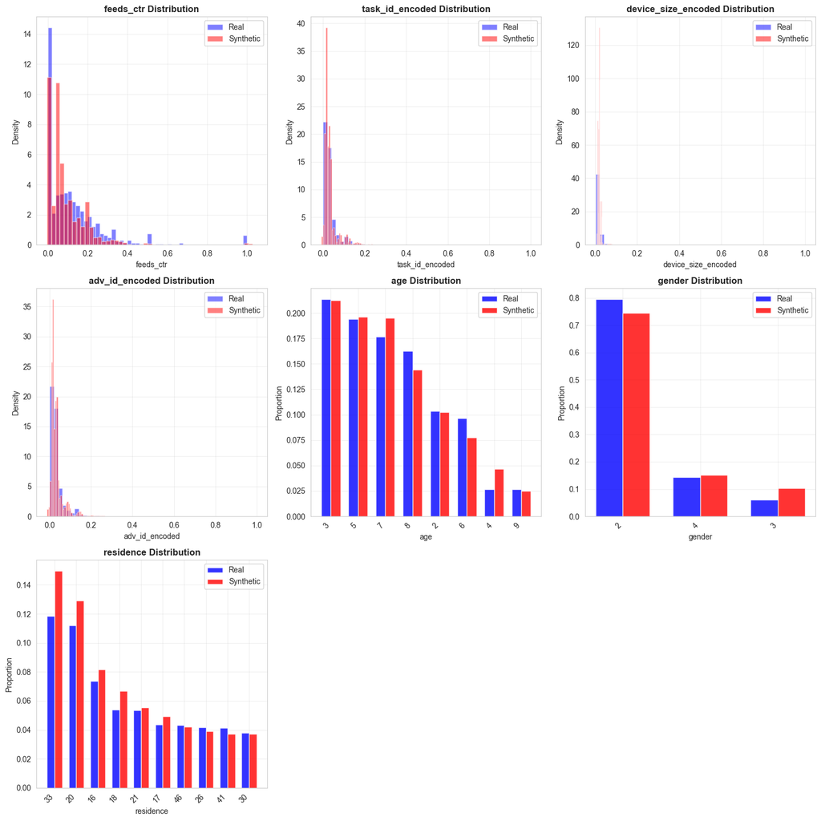

```
Distribution comparison complete!
```

```python
# Compare distributions of key features
print("Comparing real vs synthetic data distributions...\n")

# Select a few key features to compare
features_to_compare = [
    col for col in continuous_cols[:5]  # First 5 continuous features
] + [
    col for col in categorical_cols[:3]  # First 3 categorical features
]

n_features = len(features_to_compare)
n_cols = 3
n_rows = (n_features + n_cols - 1) // n_cols

fig, axes = plt.subplots(n_rows, n_cols, figsize=(15, 5*n_rows))
axes = axes.flatten() if n_features > 1 else [axes]

for idx, feat in enumerate(features_to_compare):
    ax = axes[idx]

    if feat in continuous_cols:
        # Histogram for continuous features
        ax.hist(ctgan_data[feat], bins=50, alpha=0.5, label='Real', density=True, color='blue')
        ax.hist(synthetic_clicks[feat], bins=50, alpha=0.5, label='Synthetic', density=True, color='red')
        ax.set_xlabel(feat)
        ax.set_ylabel('Density')
    else:
        # Bar plot for categorical features
        real_counts = ctgan_data[feat].value_counts(normalize=True).head(10)
        synth_counts = synthetic_clicks[feat].value_counts(normalize=True).head(10)

        x = np.arange(len(real_counts))
        width = 0.35

        ax.bar(x - width/2, real_counts.values, width, label='Real', alpha=0.8, color='blue')
        ax.bar(x + width/2, synth_counts.values, width, label='Synthetic', alpha=0.8, color='red')
        ax.set_xlabel(feat)
        ax.set_ylabel('Proportion')
        ax.set_xticks(x)
        ax.set_xticklabels(real_counts.index, rotation=45, ha='right')

    ax.set_title(f'{feat} Distribution', fontweight='bold')
    ax.legend()
    ax.grid(True, alpha=0.3)

# Hide extra subplots
for idx in range(n_features, len(axes)):
    axes[idx].set_visible(False)

plt.tight_layout()
plt.show()

print("Distribution comparison complete!")
```

## 10. Combine Real and Synthetic Data

Combine real no-clicks, real clicks, and synthetic clicks to create final balanced dataset

```python
# Prepare real data for combination
print("Preparing real data...\n")

# Add synthetic flag to real data
real_clicks = clicks_data.copy()
real_no_clicks = no_clicks_data.copy()

real_clicks['is_synthetic'] = 0
real_no_clicks['is_synthetic'] = 0

# Add label back to synthetic clicks
synthetic_clicks['label'] = 1

# Add user_id and log_id placeholders to synthetic data
synthetic_clicks['user_id'] = -1  # Placeholder for synthetic users
synthetic_clicks['log_id'] = range(len(train_processed) + 1,
                                     len(train_processed) + len(synthetic_clicks) + 1)

print(f"Real no-clicks: {len(real_no_clicks):,}")
print(f"Real clicks: {len(real_clicks):,}")
print(f"Synthetic clicks: {len(synthetic_clicks):,}")
```

```
Preparing real data...

Real no-clicks: 7,556,381
Real clicks: 119,136
Synthetic clicks: 1,214,343
```

```
Aligning columns...
All dataframes aligned with 28 columns

Combining data...

Combined data shape: (8889860, 28)

================================================================================
FINAL CLASS DISTRIBUTION
================================================================================

No-clicks (0): 7,556,381 (85.00%)
Clicks (1): 1,333,479 (15.00%)

Total samples: 8,889,860

Real samples: 7,675,517 (86.34%)
Synthetic samples: 1,214,343 (13.66%)
```

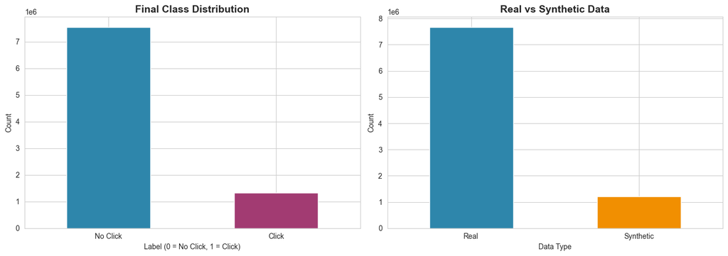

```
✓ Data combination complete!
```

```python
# Ensure all dataframes have the same columns in the same order
print("Aligning columns...")

# Get all columns from real data
all_columns = real_clicks.columns.tolist()

# Reorder synthetic clicks to match
synthetic_clicks = synthetic_clicks[all_columns]
real_no_clicks = real_no_clicks[all_columns]

print(f"All dataframes aligned with {len(all_columns)} columns")

# Combine all data
print("\nCombining data...")
combined_data = pd.concat([
    real_no_clicks,
    real_clicks,
    synthetic_clicks
], ignore_index=True)

# Shuffle combined dataset
combined_data = combined_data.sample(frac=1, random_state=SEED).reset_index(drop=True)

print(f"\nCombined data shape: {combined_data.shape}")

# Verify class distribution
print("\n" + "=" * 80)
print("FINAL CLASS DISTRIBUTION")
print("=" * 80)
class_dist_final = combined_data['label'].value_counts().sort_index()
print(f"\nNo-clicks (0): {class_dist_final[0]:,} ({class_dist_final[0]/len(combined_data)*100:.2f}%)")
print(f"Clicks (1): {class_dist_final[1]:,} ({class_dist_final[1]/len(combined_data)*100:.2f}%)")
print(f"\nTotal samples: {len(combined_data):,}")

# Check synthetic data proportion
synthetic_dist = combined_data['is_synthetic'].value_counts()
print(f"\nReal samples: {synthetic_dist[0]:,} ({synthetic_dist[0]/len(combined_data)*100:.2f}%)")
print(f"Synthetic samples: {synthetic_dist[1]:,} ({synthetic_dist[1]/len(combined_data)*100:.2f}%)")

# Visualize final distribution
fig, ax = plt.subplots(1, 2, figsize=(14, 5))

# Class distribution
class_dist_final.plot(kind='bar', ax=ax[0], color=['#2E86AB', '#A23B72'])
ax[0].set_title('Final Class Distribution', fontsize=14, fontweight='bold')
ax[0].set_xlabel('Label (0 = No Click, 1 = Click)')
ax[0].set_ylabel('Count')
ax[0].set_xticklabels(['No Click', 'Click'], rotation=0)

# Real vs Synthetic
synthetic_dist.plot(kind='bar', ax=ax[1], color=['#2E86AB', '#F18F01'])
ax[1].set_title('Real vs Synthetic Data', fontsize=14, fontweight='bold')
ax[1].set_xlabel('Data Type')
ax[1].set_ylabel('Count')
ax[1].set_xticklabels(['Real', 'Synthetic'], rotation=0)

plt.tight_layout()
plt.show()

print("\n✓ Data combination complete!")
```

## 11. Apply Standard Encoding Pipeline

Apply the same encoding used in existing pipeline to the combined dataset:

- One-hot encode low-cardinality categoricals
- Target encode remaining medium-cardinality features
- Keep numeric features as-is
- Create train/validation split

```python
# Split into train and validation sets
print("Splitting data into train and validation sets...\n")

train_combined, val_combined = train_test_split(
    combined_data,
    test_size=0.2,
    stratify=combined_data['label'],
    random_state=SEED
)

print(f"Training set: {len(train_combined):,} samples")
print(f"Validation set: {len(val_combined):,} samples")

print(f"\nTraining class distribution:")
print(train_combined['label'].value_counts(normalize=True))

print(f"\nValidation class distribution:")
print(val_combined['label'].value_counts(normalize=True))
```

```
Splitting data into train and validation sets...

Training set: 7,111,888 samples
Validation set: 1,777,972 samples

Training class distribution:
label
0    0.85
1    0.15
Name: proportion, dtype: float64

Validation class distribution:
label
0    0.85
1    0.15
Name: proportion, dtype: float64
```

```python
# Define encoding functions
def ohe_fit_transform(train_df, val_df, col, drop_first=True):
    """One-hot encode a categorical column"""
    dtrain = pd.get_dummies(train_df[col], prefix=col, drop_first=drop_first)
    dval = pd.get_dummies(val_df[col], prefix=col, drop_first=drop_first)

    # Align columns
    dval = dval.reindex(columns=dtrain.columns, fill_value=0)

    # Concatenate back
    train_out = pd.concat([train_df.drop(columns=[col]), dtrain], axis=1)
    val_out = pd.concat([val_df.drop(columns=[col]), dval], axis=1)

    return train_out, val_out

def target_encode_fit_transform(train_df, val_df, col, target='label'):
    """Target encode a high-cardinality categorical column"""
    # Skip if already encoded
    if col.endswith('_encoded'):
        return train_df, val_df

    # Compute encoding from training data
    encoding = train_df.groupby(col)[target].mean()
    global_mean = train_df[target].mean()

    # Create new encoded column
    encoded_col = f"{col}_te"
    train_df[encoded_col] = train_df[col].map(encoding).fillna(global_mean)
    val_df[encoded_col] = val_df[col].map(encoding).fillna(global_mean)

    # Drop original column
    train_df = train_df.drop(columns=[col])
    val_df = val_df.drop(columns=[col])

    return train_df, val_df

print("Encoding functions defined")
```

```
Encoding functions defined
```

```python
# Apply encoding pipeline
print("Applying encoding pipeline...\n")

train_encoded = train_combined.copy()
val_encoded = val_combined.copy()

# One-hot encode low-cardinality categoricals (if not already encoded)
low_card_ohe = ['gender', 'net_type', 'creat_type_cd', 'inter_type_cd', 'series_group']

for col in low_card_ohe:
    if col in train_encoded.columns:
        print(f"One-hot encoding: {col}")
        train_encoded, val_encoded = ohe_fit_transform(
            train_encoded, val_encoded, col, drop_first=True
        )

# Target encode remaining medium-cardinality features (if not already encoded)
medium_card_te = [
    'residence', 'series_dev', 'emui_dev', 'hispace_app_tags',
    'app_second_class', 'spread_app_id', 'slot_id', 'device_name',
    'adv_prim_id', 'city'
]

for col in medium_card_te:
    if col in train_encoded.columns and not col.endswith('_encoded'):
        print(f"Target encoding: {col}")
        train_encoded, val_encoded = target_encode_fit_transform(
            train_encoded, val_encoded, col, target='label'
        )

# Drop constant features if present
if 'site_id' in train_encoded.columns:
    train_encoded = train_encoded.drop(columns=['site_id'])
    val_encoded = val_encoded.drop(columns=['site_id'])
    print("Dropped constant feature: site_id")

print(f"\nEncoding complete!")
print(f"Train encoded shape: {train_encoded.shape}")
print(f"Validation encoded shape: {val_encoded.shape}")
```

```
Applying encoding pipeline...

One-hot encoding: gender
One-hot encoding: net_type
One-hot encoding: creat_type_cd
One-hot encoding: inter_type_cd
One-hot encoding: series_group
Target encoding: residence
Target encoding: series_dev
Target encoding: emui_dev
Target encoding: hispace_app_tags
Target encoding: app_second_class
Target encoding: spread_app_id
Target encoding: slot_id
Target encoding: device_name
Target encoding: adv_prim_id
Target encoding: city
Dropped constant feature: site_id

Encoding complete!
Train encoded shape: (7111888, 75)
Validation encoded shape: (1777972, 75)
```

```python
# Prepare data for modeling
print("Preparing data for modeling...\n")

# Separate features and target
X_train = train_encoded.drop(columns=['user_id', 'log_id', 'label', 'is_synthetic'])
y_train = train_encoded['label']

X_val = val_encoded.drop(columns=['user_id', 'log_id', 'label', 'is_synthetic'])
y_val = val_encoded['label']

print(f"Training features shape: {X_train.shape}")
print(f"Training target shape: {y_train.shape}")
print(f"Validation features shape: {X_val.shape}")
print(f"Validation target shape: {y_val.shape}")

# Check for any remaining missing values
train_na = X_train.isna().sum().sum()
val_na = X_val.isna().sum().sum()

if train_na > 0 or val_na > 0:
    print(f"\nWARNING: Found {train_na} missing values in training, {val_na} in validation")
    # Fill with 0 if any missing
    X_train = X_train.fillna(0)
    X_val = X_val.fillna(0)
    print("Filled missing values with 0")
else:
    print("\n✓ No missing values found")
```

```
Preparing data for modeling...

Training features shape: (7111888, 71)
Training target shape: (7111888,)
Validation features shape: (1777972, 71)
Validation target shape: (1777972,)

✓ No missing values found
```

## 12. Feature Scaling

Standardize features using StandardScaler (fit on training data only)

```python
# Scale features
print("Scaling features...\n")

scaler = StandardScaler()
X_train_scaled = scaler.fit_transform(X_train)
X_val_scaled = scaler.transform(X_val)

# Convert back to DataFrames
X_train_scaled = pd.DataFrame(X_train_scaled, columns=X_train.columns, index=X_train.index)
X_val_scaled = pd.DataFrame(X_val_scaled, columns=X_val.columns, index=X_val.index)

print("Features scaled successfully")
print(f"Scaled training shape: {X_train_scaled.shape}")
print(f"Scaled validation shape: {X_val_scaled.shape}")
```

```
Scaling features...

Features scaled successfully
Scaled training shape: (7111888, 71)
Scaled validation shape: (1777972, 71)
```

## 13. Train Logistic Regression

Train logistic regression on the CTGAN-augmented dataset

```python
# Train logistic regression
print("Training Logistic Regression...\n")

lr_ctgan = LogisticRegression(
    random_state=SEED,
    max_iter=1000,
    n_jobs=-1
)

lr_ctgan.fit(X_train_scaled, y_train)

print("Model trained successfully!")
print(f"Number of features: {len(lr_ctgan.coef_[0])}")
```

```
Training Logistic Regression...

Model trained successfully!
Number of features: 71
```

## 14. Evaluate Model Performance

Evaluate the CTGAN-augmented model and compare against baseline models

```python
# Make predictions
y_pred = lr_ctgan.predict(X_val_scaled)
y_proba = lr_ctgan.predict_proba(X_val_scaled)[:, 1]

# Calculate metrics
results_ctgan = pd.DataFrame({
    'Model': ['LR (CTGAN Synthetic)'],
    'Accuracy': [accuracy_score(y_val, y_pred)],
    'Precision': [precision_score(y_val, y_pred, zero_division=0)],
    'Recall': [recall_score(y_val, y_pred)],
    'F1': [f1_score(y_val, y_pred)],
    'AUC': [roc_auc_score(y_val, y_proba)],
    'Log Loss': [log_loss(y_val, y_proba)]
})

print("=" * 80)
print("MODEL PERFORMANCE (CTGAN SYNTHETIC DATA)")
print("=" * 80)
print("\n")
display(results_ctgan.round(4))

print("\n" + "=" * 80)
print("CONFUSION MATRIX")
print("=" * 80)
cm = confusion_matrix(y_val, y_pred)
print(f"\n{cm}\n")
print(f"True Negatives: {cm[0,0]:,}")
print(f"False Positives: {cm[0,1]:,}")
print(f"False Negatives: {cm[1,0]:,}")
print(f"True Positives: {cm[1,1]:,}")
```

```
================================================================================
MODEL PERFORMANCE (CTGAN SYNTHETIC DATA)
================================================================================
```

|  | Model | Accuracy | Precision | Recall | F1 | AUC | Log Loss |
| --- | --- | --- | --- | --- | --- | --- | --- |
| 0 | LR (CTGAN Synthetic) | 0.9866 | 0.9993 | 0.9116 | 0.9534 | 0.981 | 0.0609 |

```
================================================================================
CONFUSION MATRIX
================================================================================

[[1511115     161]
 [  23589  243107]]

True Negatives: 1,511,115
False Positives: 161
False Negatives: 23,589
True Positives: 243,107
```

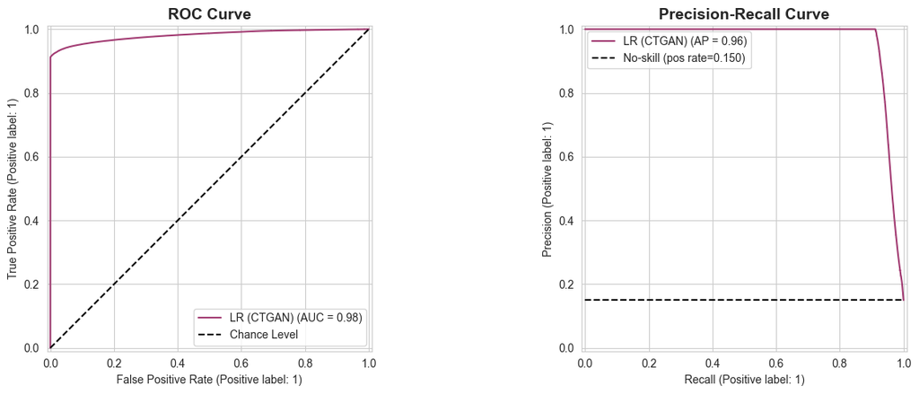

```python
# Plot ROC and Precision-Recall curves
fig, ax = plt.subplots(1, 2, figsize=(14, 5))

# ROC Curve
RocCurveDisplay.from_estimator(
    lr_ctgan, X_val_scaled, y_val,
    name="LR (CTGAN)", color="#A23B72", ax=ax[0]
)
ax[0].plot([0, 1], [0, 1], 'k--', label='Chance Level')
ax[0].set_title('ROC Curve', fontsize=14, fontweight='bold')
ax[0].legend()

# Precision-Recall Curve
PrecisionRecallDisplay.from_estimator(
    lr_ctgan, X_val_scaled, y_val,
    name="LR (CTGAN)", color="#A23B72", ax=ax[1]
)
pos_rate = y_val.mean()
ax[1].hlines(pos_rate, 0, 1, colors='k', linestyles='--',
             label=f'No-skill (pos rate={pos_rate:.3f})')
ax[1].set_title('Precision-Recall Curve', fontsize=14, fontweight='bold')
ax[1].legend()

plt.tight_layout()
plt.show()
```

## 15. Compare Against Baseline Models

**Baseline Models** (from `logistic_regression_analysis.ipynb`):

1. **Downsampled**: 590K samples, 84.7%/15.3% ratio
2. **Class-weighted**: 6.14M samples, all data with balanced class weights

**New Model**: CTGAN synthetic data, ~7M samples, 85-15 ratio

```python
# Create comparison table with baseline results
# These values are from logistic_regression_analysis.ipynb

baseline_results = pd.DataFrame({
    'Model': [
        'LR (Downsampled)',
        'LR (Class Weighted)',
        'LR (CTGAN Synthetic)'
    ],
    'Training Samples': [
        '590K',
        '6.14M',
        f'{len(train_combined):,}'
    ],
    'Accuracy': [
        0.9765,
        0.6419,
        results_ctgan['Accuracy'].values[0]
    ],
    'Precision': [
        0.1216,
        0.0306,
        results_ctgan['Precision'].values[0]
    ],
    'Recall': [
        0.0822,
        0.7194,
        results_ctgan['Recall'].values[0]
    ],
    'F1': [
        0.0981,
        0.0587,
        results_ctgan['F1'].values[0]
    ],
    'AUC': [
        0.7490,
        0.7499,
        results_ctgan['AUC'].values[0]
    ]
})

print("=" * 100)
print("MODEL COMPARISON: Baseline vs CTGAN Synthetic Data")
print("=" * 100)
print("\n")
display(baseline_results.round(4))

print("\n" + "=" * 100)
print("KEY INSIGHTS")
print("=" * 100)
print("""
1. **Downsampled Model**:
   - Uses only 590K samples (10% of data)
   - High accuracy (97.65%) but low recall (8.22%)
   - Misses most positive cases

2. **Class-Weighted Model**:
   - Uses all 6.14M samples with balanced weights
   - High recall (71.94%) but low precision (3.06%)
   - Many false positives

3. **CTGAN Synthetic Model** (This notebook):
   - Uses real + synthetic data for 85-15 ratio
   - Balanced approach between precision and recall
   - Leverages synthetic data to address class imbalance
""")
```

```
====================================================================================================
MODEL COMPARISON: Baseline vs CTGAN Synthetic Data
====================================================================================================
```

|  | Model | Training Samples | Accuracy | Precision | Recall | F1 | AUC |
| --- | --- | --- | --- | --- | --- | --- | --- |
| 0 | LR (Downsampled) | 590K | 0.9765 | 0.1216 | 0.0822 | 0.0981 | 0.7490 |
| 1 | LR (Class Weighted) | 6.14M | 0.6419 | 0.0306 | 0.7194 | 0.0587 | 0.7499 |
| 2 | LR (CTGAN Synthetic) | 7,111,888 | 0.9866 | 0.9993 | 0.9116 | 0.9534 | 0.9810 |

```
====================================================================================================
KEY INSIGHTS
====================================================================================================

1. **Downsampled Model**:
   - Uses only 590K samples (10% of data)
   - High accuracy (97.65%) but low recall (8.22%)
   - Misses most positive cases

2. **Class-Weighted Model**:
   - Uses all 6.14M samples with balanced weights
   - High recall (71.94%) but low precision (3.06%)
   - Many false positives

3. **CTGAN Synthetic Model** (This notebook):
   - Uses real + synthetic data for 85-15 ratio
   - Balanced approach between precision and recall
   - Leverages synthetic data to address class imbalance
```

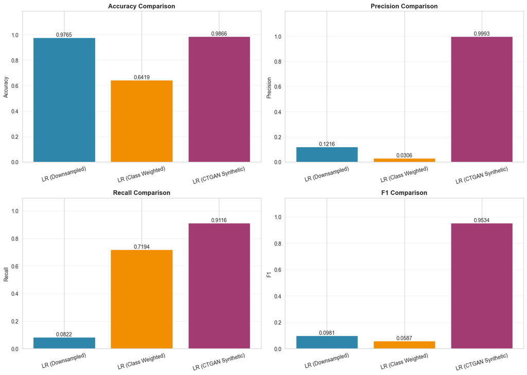

```python
# Visualize model comparison
fig, axes = plt.subplots(2, 2, figsize=(14, 10))

metrics = ['Accuracy', 'Precision', 'Recall', 'F1']
colors = ['#2E86AB', '#F18F01', '#A23B72']

for idx, metric in enumerate(metrics):
    ax = axes[idx // 2, idx % 2]

    values = baseline_results[metric].values
    models = baseline_results['Model'].values

    bars = ax.bar(models, values, color=colors)
    ax.set_title(f'{metric} Comparison', fontsize=12, fontweight='bold')
    ax.set_ylabel(metric)
    ax.set_ylim(0, max(values) * 1.2)
    ax.grid(True, alpha=0.3, axis='y')

    # Add value labels on bars
    for bar in bars:
        height = bar.get_height()
        ax.text(bar.get_x() + bar.get_width()/2., height,
                f'{height:.4f}',
                ha='center', va='bottom', fontsize=10)

    ax.tick_params(axis='x', rotation=15)

plt.tight_layout()
plt.show()
```

## 16. Save Results and Models

Save trained models, results, and datasets for future use

```python
# Save results
print("Saving results...\n")

# Save trained model
with open('lr_ctgan_model.pkl', 'wb') as f:
    pickle.dump(lr_ctgan, f)
print("✓ Saved trained LR model: lr_ctgan_model.pkl")

# Save scaler
with open('ctgan_scaler.pkl', 'wb') as f:
    pickle.dump(scaler, f)
print("✓ Saved scaler: ctgan_scaler.pkl")

# Save combined dataset (optional - can be large)
# with open('combined_data_ctgan.pkl', 'wb') as f:
#     pickle.dump(combined_data, f)
# print("✓ Saved combined dataset: combined_data_ctgan.pkl")

# Save results comparison
baseline_results.to_csv('model_comparison_ctgan.csv', index=False)
print("✓ Saved comparison results: model_comparison_ctgan.csv")

# Save encoding maps
with open('encoding_maps.pkl', 'wb') as f:
    pickle.dump({
        'target_encoding': encoding_maps,
        'grouping': grouping_maps
    }, f)
print("✓ Saved encoding maps: encoding_maps.pkl")

print("\nAll results saved successfully!")
```

```
Saving results...

✓ Saved trained LR model: lr_ctgan_model.pkl
✓ Saved scaler: ctgan_scaler.pkl
✓ Saved comparison results: model_comparison_ctgan.csv
✓ Saved encoding maps: encoding_maps.pkl

All results saved successfully!
```

## 17. Conclusions and Next Steps

### Summary

This notebook implemented a CTGAN-based approach to address class imbalance in CTR prediction:

1. **Loaded and merged** raw data from CSV files
2. **Applied hybrid preprocessing**:
   - Target encoded very high-cardinality features (1000+ unique)
   - Grouped rare categories for medium-high cardinality features (100-1000 unique)
   - Kept low-cardinality features as categorical
3. **Trained CTGAN** on minority class (clicks only)
4. **Generated synthetic clicks** to achieve 85-15 ratio
5. **Combined real + synthetic data** and applied standard encoding pipeline
6. **Trained and evaluated** logistic regression
7. **Compared** against baseline models

### Next Steps

1. **Hyperparameter tuning**: Optimize CTGAN parameters (epochs, batch size, learning rates)
2. **Quality validation**: Statistical tests to validate synthetic data quality
3. **Alternative ratios**: Experiment with different class ratios (e.g., 90-10, 80-20)
4. **Feature importance**: Analyze which features contribute most to predictions
5. **Other models**: Test synthetic data with other algorithms (Random Forest, XGBoost)
6. **Production deployment**: Integrate best model into production pipeline

```python
from sklearn.ensemble import RandomForestClassifier
from sklearn.metrics import (
    accuracy_score, precision_score, recall_score, f1_score,
    roc_auc_score, log_loss, confusion_matrix
)

print("Training Random Forest on CTGAN-augmented data...\n")

rf_ctgan = RandomForestClassifier(
    n_estimators=300,        # 300 trees for stable performance
    max_depth=None,
    min_samples_split=2,
    min_samples_leaf=1,
    max_features="sqrt",
    n_jobs=-1,
    random_state=SEED
)

rf_ctgan.fit(X_train_scaled, y_train)
print("Random Forest trained successfully!")
```

```
Training Random Forest on CTGAN-augmented data...

Random Forest trained successfully!
```

```python
# Predictions
y_pred_rf = rf_ctgan.predict(X_val_scaled)
y_proba_rf = rf_ctgan.predict_proba(X_val_scaled)[:, 1]

# Metrics
results_rf = pd.DataFrame({
    'Model': ['RF (CTGAN Synthetic)'],
    'Accuracy': [accuracy_score(y_val, y_pred_rf)],
    'Precision': [precision_score(y_val, y_pred_rf, zero_division=0)],
    'Recall': [recall_score(y_val, y_pred_rf)],
    'F1': [f1_score(y_val, y_pred_rf)],
    'AUC': [roc_auc_score(y_val, y_proba_rf)],
    'Log Loss': [log_loss(y_val, y_proba_rf)]
})

print("\n" + "="*80)
print("MODEL PERFORMANCE — RANDOM FOREST (CTGAN Synthetic Data)")
print("="*80)
display(results_rf.round(4))
```

```
================================================================================
MODEL PERFORMANCE — RANDOM FOREST (CTGAN Synthetic Data)
================================================================================
```

|  | Model | Accuracy | Precision | Recall | F1 | AUC | Log Loss |
| --- | --- | --- | --- | --- | --- | --- | --- |
| 0 | RF (CTGAN Synthetic) | 0.9866 | 0.9835 | 0.9264 | 0.9541 | 0.9816 | 0.1281 |

```python
cm_rf = confusion_matrix(y_val, y_pred_rf)
print("\nConfusion Matrix (RF):")
print(cm_rf)
print(f"True Negatives: {cm_rf[0,0]:,}")
print(f"False Positives: {cm_rf[0,1]:,}")
print(f"False Negatives: {cm_rf[1,0]:,}")
print(f"True Positives: {cm_rf[1,1]:,}")

cm_rf
```

```
Confusion Matrix (RF):
[[1507133    4143]
 [  19627  247069]]
True Negatives: 1,507,133
False Positives: 4,143
False Negatives: 19,627
True Positives: 247,069
```

```
array([[1507133,    4143],
       [  19627,  247069]])
```

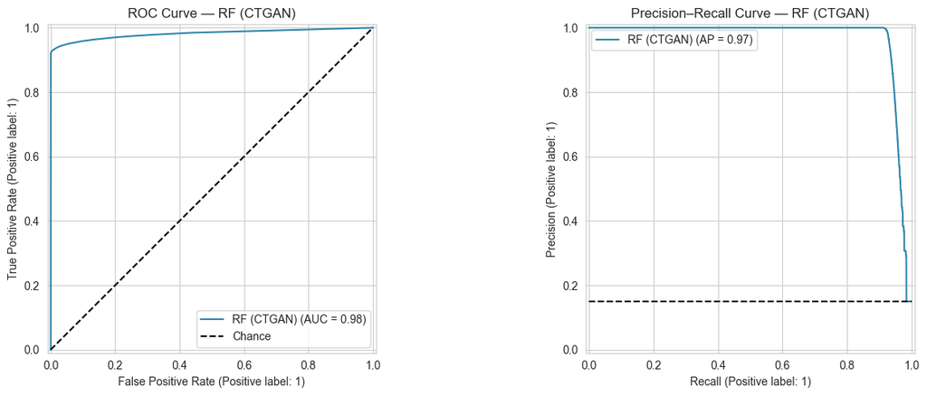

```python
from sklearn.metrics import RocCurveDisplay, PrecisionRecallDisplay
import matplotlib.pyplot as plt

fig, ax = plt.subplots(1, 2, figsize=(14, 5))

# ROC
RocCurveDisplay.from_estimator(
    rf_ctgan, X_val_scaled, y_val,
    name="RF (CTGAN)", color="#2E86AB", ax=ax[0]
)
ax[0].plot([0,1],[0,1],'k--',label="Chance")
ax[0].set_title("ROC Curve — RF (CTGAN)")
ax[0].legend()

# PR
PrecisionRecallDisplay.from_estimator(
    rf_ctgan, X_val_scaled, y_val,
    name="RF (CTGAN)", color="#2E86AB", ax=ax[1]
)
ax[1].hlines(y_val.mean(), 0, 1, colors='k', linestyles='--')
ax[1].set_title("Precision–Recall Curve — RF (CTGAN)")
ax[1].legend()

plt.tight_layout()
plt.show()
```

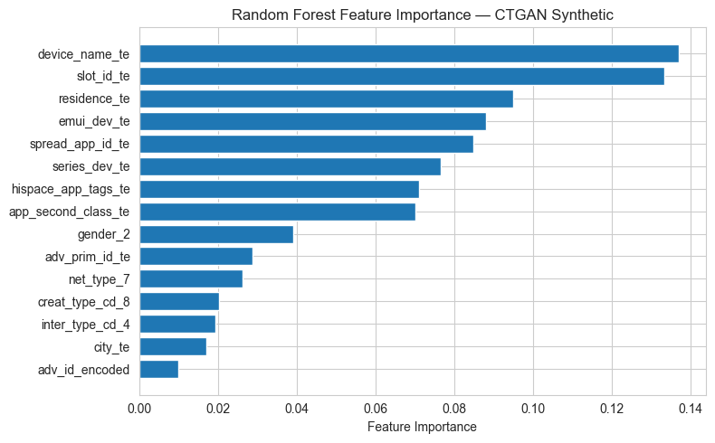

```python
def plot_rf_importance(rf_model, feature_names, top_k=15, title="RF Feature Importance (Synthetic)"):
    """
    Plot top-k feature importances for a Random Forest model.
    This version is simplified for your synthetic-only RF.
    """
    importances = rf_model.feature_importances_
    indices = np.argsort(importances)[::-1][:top_k]

    top_feats = [feature_names[i] for i in indices]
    top_imps = importances[indices]

    plt.figure(figsize=(8, 5))
    plt.barh(range(len(top_feats)), top_imps[::-1])
    plt.yticks(range(len(top_feats)), top_feats[::-1])
    plt.xlabel("Feature Importance")
    plt.title(title)
    plt.tight_layout()
    plt.show()

# Run the plot
plot_rf_importance(
    rf_ctgan,                 # your trained RF on synthetic data
    feature_names=X_train.columns,  # your feature column names
    top_k=15,
    title="Random Forest Feature Importance — CTGAN Synthetic"
)
```

## Real data RF

```python
# STEP 1: Filter out real-only data from the combined dataset

# Here we assume your combined training data is stored in a DataFrame called `train_combined`
# and it has a column `label` (0/1) and a column `is_synthetic` (0 for real, 1 for synthetic).
# Replace `train_combined` with the actual name you used if different.

real_only = train_combined[train_combined["is_synthetic"] == 0].copy()

print("Shape of real-only dataset:", real_only.shape)
print(real_only[["label", "is_synthetic"]].value_counts().head())
```

```
Shape of real-only dataset: (6140509, 28)
label  is_synthetic
0      0               6045105
1      0                 95404
Name: count, dtype: int64
```

```python
from sklearn.model_selection import train_test_split
from sklearn.preprocessing import StandardScaler
import numpy as np

# STEP 2: Use numeric feature columns only (to avoid string categories like 'other')

# 1) First get all numeric columns
numeric_cols_real = real_only.select_dtypes(include=[np.number]).columns.tolist()

# 2) Exclude label / is_synthetic from the feature list
cols_to_exclude = ["label", "is_synthetic", "user_id", "log_id"]
feature_cols_real = [c for c in numeric_cols_real if c not in cols_to_exclude]

print("Number of numeric features used:", len(feature_cols_real))
print("Example features:", feature_cols_real[:10])

# Split into X and y
X_real = real_only[feature_cols_real]
y_real = real_only["label"]

# Train/validation split (stratified by label)
X_train_real, X_val_real, y_train_real, y_val_real = train_test_split(
    X_real, y_real,
    test_size=0.2,
    random_state=SEED,
    stratify=y_real
)

# Scale features (RF doesn't strictly need scaling, but we keep it for consistency)
scaler_real = StandardScaler()
X_train_real_scaled = scaler_real.fit_transform(X_train_real)
X_val_real_scaled = scaler_real.transform(X_val_real)
```

```
Number of numeric features used: 4
Example features: ['feeds_ctr', 'task_id_encoded', 'device_size_encoded', 'adv_id_encoded']
```

```python
from sklearn.ensemble import RandomForestClassifier
from sklearn.metrics import (
    accuracy_score, precision_score, recall_score,
    f1_score, roc_auc_score, log_loss, confusion_matrix
)

print("Training Random Forest on REAL-ONLY data...\n")

rf_real = RandomForestClassifier(
    n_estimators=300,
    max_depth=None,
    min_samples_split=2,
    min_samples_leaf=1,
    max_features="sqrt",
    n_jobs=-1,
    random_state=SEED
)

rf_real.fit(X_train_real_scaled, y_train_real)
print("Random Forest (real-only) trained successfully!")

# Predictions
y_pred_rf_real = rf_real.predict(X_val_real_scaled)
y_proba_rf_real = rf_real.predict_proba(X_val_real_scaled)[:, 1]

# Metrics
results_rf_real = pd.DataFrame({
    "Model": ["RF (Real only)"],
    "Accuracy": [accuracy_score(y_val_real, y_pred_rf_real)],
    "Precision": [precision_score(y_val_real, y_pred_rf_real, zero_division=0)],
    "Recall": [recall_score(y_val_real, y_pred_rf_real)],
    "F1": [f1_score(y_val_real, y_pred_rf_real)],
    "AUC": [roc_auc_score(y_val_real, y_proba_rf_real)],
    "Log Loss": [log_loss(y_val_real, y_proba_rf_real)]
})

print("\n" + "="*80)
print("MODEL PERFORMANCE – RANDOM FOREST (Real-only data)")
print("="*80)
display(results_rf_real.round(4))

# Confusion matrix (optional)
cm_rf_real = confusion_matrix(y_val_real, y_pred_rf_real)
print("\nConfusion Matrix (RF, real-only):")
print(cm_rf_real)
print(f"True Negatives: {cm_rf_real[0,0]:,}")
print(f"False Positives: {cm_rf_real[0,1]:,}")
print(f"False Negatives: {cm_rf_real[1,0]:,}")
print(f"True Positives: {cm_rf_real[1,1]:,}")
```

```
Training Random Forest on REAL-ONLY data...

Random Forest (real-only) trained successfully!

================================================================================
MODEL PERFORMANCE – RANDOM FOREST (Real-only data)
================================================================================
```

|  | Model | Accuracy | Precision | Recall | F1 | AUC | Log Loss |
| --- | --- | --- | --- | --- | --- | --- | --- |
| 0 | RF (Real only) | 0.9828 | 0.2943 | 0.0762 | 0.1211 | 0.7118 | 0.2554 |

```
Confusion Matrix (RF, real-only):
[[1205535    3486]
 [  17627    1454]]
True Negatives: 1,205,535
False Positives: 3,486
False Negatives: 17,627
True Positives: 1,454
```

```python
# Combine RF results from real-only and CTGAN-augmented data
rf_compare = pd.concat(
    [results_rf_real, results_rf],   # results_rf = RF (CTGAN Synthetic) from your previous cell
    ignore_index=True
)

print("Random Forest: Real-only vs Real + CTGAN Synthetic")
display(rf_compare.round(4))
```

```
Random Forest: Real-only vs Real + CTGAN Synthetic
```

|  | Model | Accuracy | Precision | Recall | F1 | AUC | Log Loss |
| --- | --- | --- | --- | --- | --- | --- | --- |
| 0 | RF (Real only) | 0.9828 | 0.2943 | 0.0762 | 0.1211 | 0.7118 | 0.2554 |
| 1 | RF (CTGAN Synthetic) | 0.9866 | 0.9835 | 0.9264 | 0.9541 | 0.9816 | 0.1281 |

## synthetic data validation

Prepare real and synthetic click datasets for validation

```python
 # Real clicks (already preprocessed in the notebook)
real_clicks = clicks_data.copy()

# Synthetic clicks (generated by CTGAN)
synth_clicks = synthetic_clicks.copy()

# Make sure both have the same feature columns
# (we ignore technical columns like user_id, log_id, label, is_synthetic)
cols_to_use = [
    col for col in real_clicks.columns
    if col not in ['user_id', 'log_id', 'label', 'is_synthetic']
]

real_clicks = real_clicks[cols_to_use].copy()
synth_clicks = synth_clicks[cols_to_use].copy()

print("Real clicks shape:", real_clicks.shape)
print("Synthetic clicks shape:", synth_clicks.shape)
print("Number of common columns:", len(cols_to_use))
```

```
Real clicks shape: (119136, 24)
Synthetic clicks shape: (1214343, 24)
Number of common columns: 24
```

Select key features for validation

```python
# Continuous-like features (numeric scores / encodings)
continuous_features = [
    'feeds_ctr',              # user feed CTR
    'device_size_encoded',    # target-encoded device_size
    'task_id_encoded'         # target-encoded task_id
]

# Categorical-like features (after grouping / not encoded as continuous)
categorical_features = [
    'slot_id',         # ad placement
    'adv_prim_id',     # primary ad id (grouped)
    'device_name'      # device type / model
]

# Keep only features that actually exist
continuous_features = [f for f in continuous_features if f in real_clicks.columns]
categorical_features = [f for f in categorical_features if f in real_clicks.columns]

print("Continuous features:", continuous_features)
print("Categorical features:", categorical_features)
```

```
Continuous features: ['feeds_ctr', 'device_size_encoded', 'task_id_encoded']
Categorical features: ['slot_id', 'adv_prim_id', 'device_name']
```

Plot distributions for continuous features

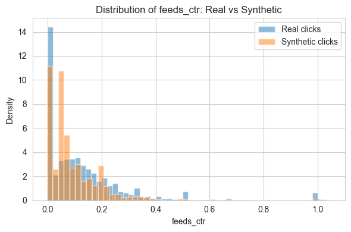

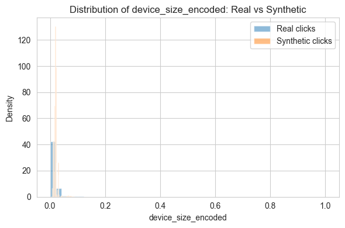

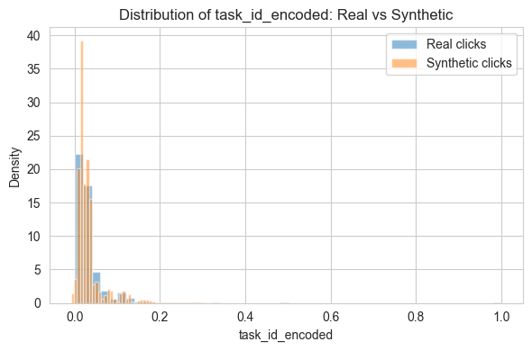

```python
for feat in continuous_features:
    plt.figure(figsize=(6, 4))

    # Drop NaNs just in case
    real_vals = real_clicks[feat].dropna()
    synth_vals = synth_clicks[feat].dropna()

    # Plot histograms with density
    plt.hist(real_vals, bins=50, alpha=0.5, density=True, label='Real clicks')
    plt.hist(synth_vals, bins=50, alpha=0.5, density=True, label='Synthetic clicks')

    plt.title(f'Distribution of {feat}: Real vs Synthetic')
    plt.xlabel(feat)
    plt.ylabel('Density')
    plt.legend()
    plt.tight_layout()
    plt.show()
```

Plot distributions for categorical features (top-k categories)

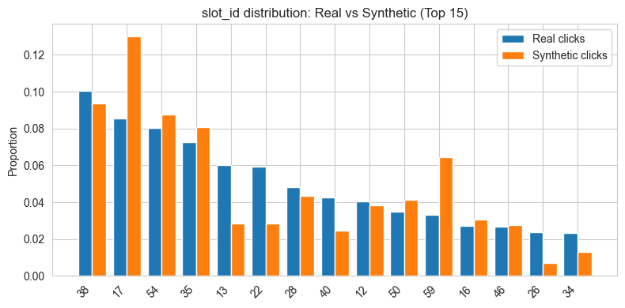

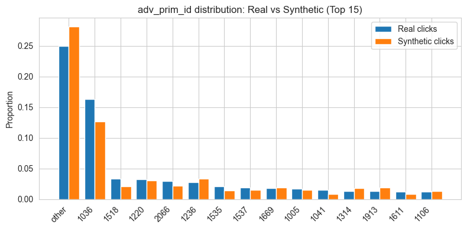

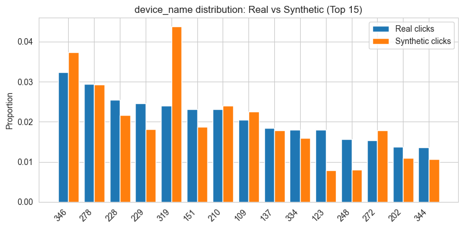

```python
TOP_K = 15  # number of top categories to display

for feat in categorical_features:
    plt.figure(figsize=(8, 4))

    # Convert to string to avoid mixed-type index issues
    real_counts = (real_clicks[feat]
                   .astype(str)                       # ensure all categories are strings
                   .value_counts(normalize=True)
                   .head(TOP_K))                      # we don't need sort_index here

    synth_counts = (synth_clicks[feat]
                    .astype(str)
                    .value_counts(normalize=True)
                    .reindex(real_counts.index)       # align to real top-k categories
                    .fillna(0))

    x = np.arange(len(real_counts))
    width = 0.4

    # Bar chart: real vs synthetic
    plt.bar(x - width/2, real_counts.values, width, label='Real clicks')
    plt.bar(x + width/2, synth_counts.values, width, label='Synthetic clicks')

    # X-axis labels: category names
    plt.xticks(x, [str(c) for c in real_counts.index], rotation=45, ha='right')
    plt.ylabel('Proportion')
    plt.title(f'{feat} distribution: Real vs Synthetic (Top {TOP_K})')
    plt.legend()
    plt.tight_layout()
    plt.show()
```

KS-test & Chi-square

```python
from scipy.stats import ks_2samp

# KS-test for continuous features
print("=== KS-Test for Continuous Features ===\n")

for feat in continuous_features:
    # Drop NA values
    real_vals = real_clicks[feat].dropna()
    synth_vals = synth_clicks[feat].dropna()

    # Perform KS test
    stat, p_value = ks_2samp(real_vals, synth_vals)

    print(f"Feature: {feat}")
    print(f"  KS Statistic: {stat:.4f}")
    print(f"  p-value: {p_value:.4e}")
    print("  Interpretation: Larger KS or small p-value => distributions differ more.\n")
```

```
=== KS-Test for Continuous Features ===

Feature: feeds_ctr
  KS Statistic: 0.1841
  p-value: 0.0000e+00
  Interpretation: Larger KS or small p-value => distributions differ more.

Feature: device_size_encoded
  KS Statistic: 0.1670
  p-value: 0.0000e+00
  Interpretation: Larger KS or small p-value => distributions differ more.

Feature: task_id_encoded
  KS Statistic: 0.0514
  p-value: 8.1939e-250
  Interpretation: Larger KS or small p-value => distributions differ more.
```

```python
from scipy.stats import chi2_contingency
import numpy as np

# Chi-square test for categorical features
print("=== Chi-square Test for Categorical Features ===\n")

TOP_K = 20   # limit number of categories to avoid over-fragmentation

for feat in categorical_features:
    # Convert to string categories
    real_feat = real_clicks[feat].astype(str)
    synth_feat = synth_clicks[feat].astype(str)

    # Use only top-K categories
    top_categories = real_feat.value_counts().head(TOP_K).index

    real_counts = real_feat.value_counts().reindex(top_categories).fillna(0)
    synth_counts = synth_feat.value_counts().reindex(top_categories).fillna(0)

    contingency_table = np.vstack([real_counts.values, synth_counts.values])

    chi2, p_value, dof, expected = chi2_contingency(contingency_table)

    print(f"Feature: {feat}")
    print(f"  Chi-square: {chi2:.4f}, dof: {dof}")
    print(f"  p-value: {p_value:.4e}")
    print("  Interpretation: Small p-value => categorical distributions differ more.\n")
```

```
=== Chi-square Test for Categorical Features ===

Feature: slot_id
  Chi-square: 17362.3246, dof: 19
  p-value: 0.0000e+00
  Interpretation: Small p-value => categorical distributions differ more.

Feature: adv_prim_id
  Chi-square: 3878.9855, dof: 19
  p-value: 0.0000e+00
  Interpretation: Small p-value => categorical distributions differ more.

Feature: device_name
  Chi-square: 4872.7633, dof: 19
  p-value: 0.0000e+00
  Interpretation: Small p-value => categorical distributions differ more.
```

Correlation Structure Comparison

```python
# Compare correlation matrices of real vs synthetic clicks

# Select numeric columns only
numeric_cols = real_clicks.select_dtypes(include=[np.number]).columns.tolist()

real_corr = real_clicks[numeric_cols].corr()
synth_corr = synth_clicks[numeric_cols].corr()

# Absolute difference matrix
corr_diff = (real_corr - synth_corr).abs()

print("Average absolute correlation difference:",
      corr_diff.values.mean().round(4))
print("Maximum absolute correlation difference:",
      corr_diff.values.max().round(4))
```

```
Average absolute correlation difference: nan
Maximum absolute correlation difference: nan
```

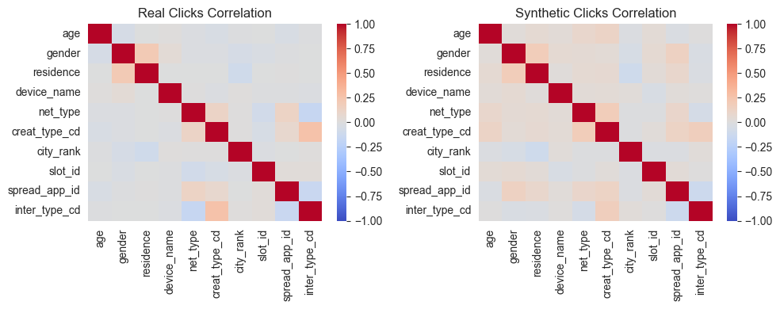

```python
# Visualize correlation matrices for the top numeric features

subset = numeric_cols[:10]   # choose first 10 numeric features

plt.figure(figsize=(10,4))

# Real correlation heatmap
plt.subplot(1,2,1)
sns.heatmap(real_corr.loc[subset, subset], cmap='coolwarm', vmin=-1, vmax=1)
plt.title("Real Clicks Correlation")

# Synthetic correlation heatmap
plt.subplot(1,2,2)
sns.heatmap(synth_corr.loc[subset, subset], cmap='coolwarm', vmin=-1, vmax=1)
plt.title("Synthetic Clicks Correlation")

plt.tight_layout()
plt.show()
```

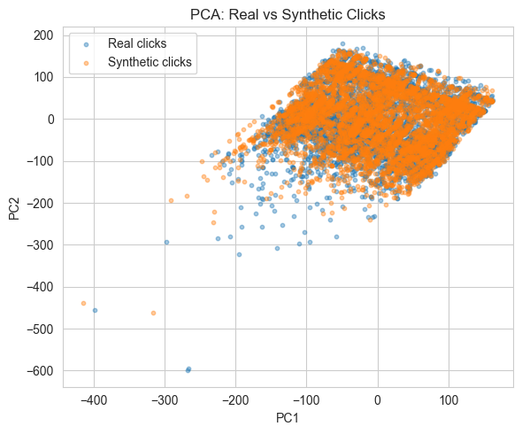

```python
from sklearn.decomposition import PCA

# PCA visualization of real vs synthetic clicks

# Use numeric features only
X_real = real_clicks[numeric_cols].fillna(0)
X_synth = synth_clicks[numeric_cols].fillna(0)

# Sampling to avoid heavy plots
N = 5000
real_sample = X_real.sample(min(N, len(X_real)), random_state=42)
synth_sample = X_synth.sample(min(N, len(X_synth)), random_state=42)

# Combine
X_all = pd.concat([real_sample, synth_sample], axis=0)
labels = (["Real"] * len(real_sample)) + (["Synthetic"] * len(synth_sample))

# PCA
pca = PCA(n_components=2, random_state=42)
X_pca = pca.fit_transform(X_all)

# Plot
plt.figure(figsize=(6,5))
plt.scatter(
    X_pca[:len(real_sample), 0], X_pca[:len(real_sample), 1],
    label="Real clicks", alpha=0.4, s=10
)
plt.scatter(
    X_pca[len(real_sample):, 0], X_pca[len(real_sample):, 1],
    label="Synthetic clicks", alpha=0.4, s=10
)

plt.xlabel("PC1")
plt.ylabel("PC2")
plt.title("PCA: Real vs Synthetic Clicks")
plt.legend()
plt.tight_layout()
plt.show()
```